# Spatial Data Analysis

Spatial Data Analysis is a process of understanding spatial relationships and patterns from the locational data.

*This notebook explains about the procedure of evaluating the factors that influence median house value by hedonic regression model.*

The data set I’m working here is *Glasgow*, which has an information of house characteristics, neighborhood characteristics of 271 neighbourhoods.

First step:

*Install all the necessary libraries*

Lets look explore the dataset. First will list out all the variables in the dataset

```r
ls(Glasgow.df) # list of all variable names
```

```
##  [1] "AREA"       "ASSAULT"    "CRIME"      "EXPRES2009" "EXPRES2010"
##  [6] "FEM2001"    "ID"         "INCOMEDEP"  "INTGEOCODE" "INTGEONAME"
## [11] "MALE2001"   "MEDPRICE"   "MEDROOM"    "NOFDWELL"   "NOFSALES"
## [16] "OBSRES2009" "OBSRES2010" "POP2001"    "SALES"      "TIMESHOP"
## [21] "TYPE"
```

**head()** function helps to view the format of the data of each variable.

```r
head(Glasgow.df, n= 2)
```

```
##   ID      AREA INTGEOCODE    INTGEONAME FEM2001 MALE2001 POP2001 NOFDWELL
## 0  3  1.061154  S02000262 Woodhill West    2339     2314    4653     1729
## 1 28 56.669419  S02000287    Lennoxtown    2270     2150    4420     1937
##   NOFSALES MEDPRICE   SALES MEDROOM    TYPE CRIME ASSAULT INCOMEDEP
## 0       34   178111 1.96645       5    semi   196      34         6
## 1       95   165000 4.90449       4 terrace   422      66         7
##   TIMESHOP OBSRES2009 OBSRES2010 EXPRES2009 EXPRES2010
## 0      1.7         46         53   94.51724   104.4924
## 1      4.8         55         81   96.74449   106.6324
```

As some of the variables are treated of characters, instead of numeric. I converted all of them into numeric.

```r
Glasgow.df[, c("MEDPRICE", "MEDROOM", "CRIME")] <-
  lapply(Glasgow.df[, c("MEDPRICE", "MEDROOM", "CRIME")],
  function(x) as.numeric(levels(x))[x])
```

Out of all the variables, we will inspect influence of top 5 features that influence house prices.

```r
Glas.frame <- Glasgow.df[c("MEDPRICE","MEDROOM","CRIME","SALES","TYPE","INCOMEDEP")]
```

### Hypothesis formulation

SALES:– *Positive* Common sense tells us that stable neighborhoods will have a low percentage of sales as people do not move out from stable neighborhoods. When a house is sold at a higher price eventually, it positively influences the median home sales price of the surrounding homes.()

MEDROOM:– *Positive* Common sense tells us that the more rooms in a dwelling, typically the more expensive the dwelling. Hence, the rooms have a positive influence over the median home sales price.

TYPE:– *Positive* Common sense tells us that the more rooms in a dwelling, typically the more expensive the dwelling. Hence, the rooms have a positive influence over the median home sales price.

CRIME:– *Negative* Common sense tells us that the more crime in an area, the more unstable the neighborhood, which brings down the values of the homes. In addition, areas with high crime, typically will have a population that is income deprived.

INCOMEDEP:– *Negative* Common sense tells us that the more crime in an area, the more unstable the neighborhood, which brings down the values of the homes. In addition, areas with high crime, typically will have a population that is income deprived.

# Variable Exploration

## Variable Exploration

### Variable Exploration

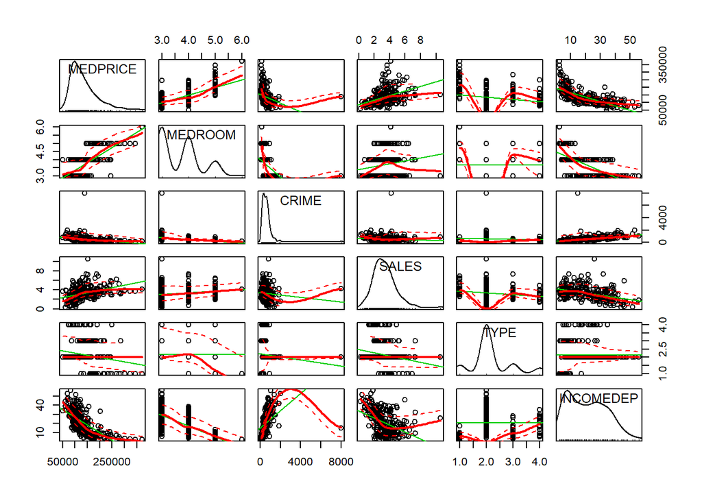

```r
scatterplotMatrix(Glas.frame)
```

```r
summary(Glas.frame)
```

```
##     MEDPRICE         MEDROOM          CRIME            SALES
##  Min.   : 50000   Min.   :3.000   Min.   :  85.0   Min.   : 0.2446
##  1st Qu.: 95000   1st Qu.:3.000   1st Qu.: 303.5   1st Qu.: 2.3335
##  Median :122000   Median :4.000   Median : 519.0   Median : 3.1174
##  Mean   :134791   Mean   :3.679   Mean   : 582.6   Mean   : 3.2948
##  3rd Qu.:158438   3rd Qu.:4.000   3rd Qu.: 733.0   3rd Qu.: 4.0743
##  Max.   :372750   Max.   :6.000   Max.   :8009.0   Max.   :10.5650
##        TYPE       INCOMEDEP
##  detached: 31   Min.   : 2.50
##  flat    :184   1st Qu.: 9.00
##  semi    : 36   Median :20.50
##  terrace : 20   Mean   :21.08
##                 3rd Qu.:31.50
##                 Max.   :56.00
```

```r
typeof(Glas.frame)
```

```
## [1] "list"
```

#### Exploring each variable in a spatial approach manner.

*Chloropath map of **Type of Dwellings** variable*

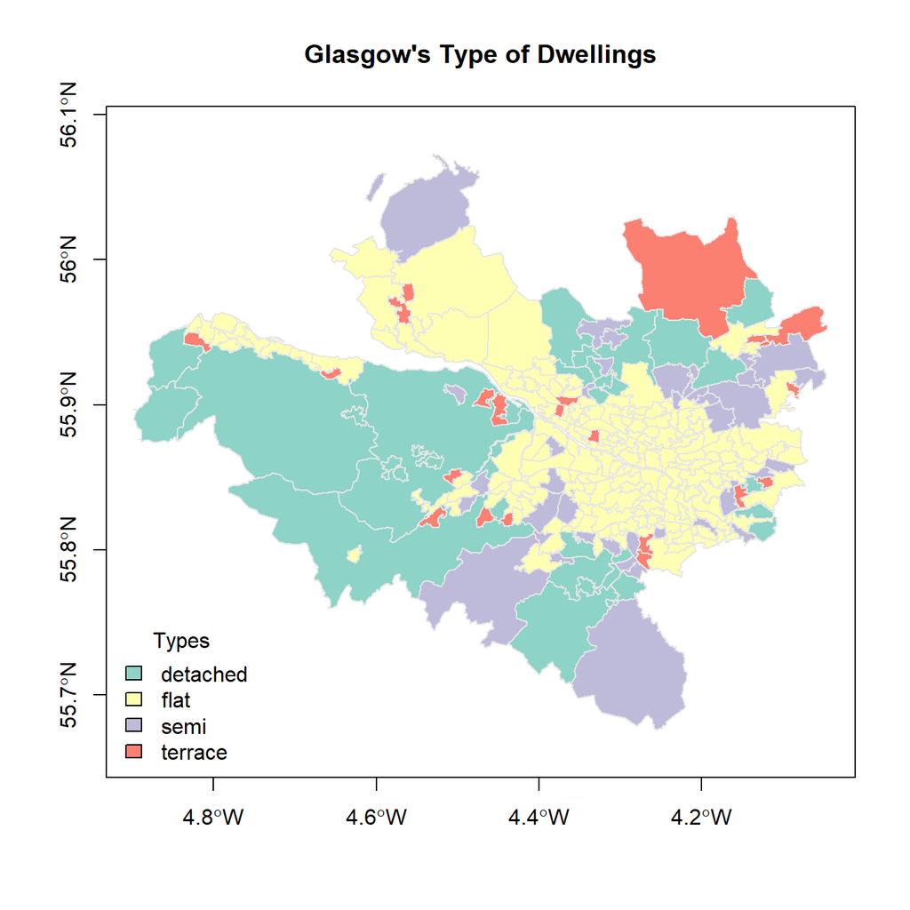

```r
library("spdep")
library("classInt")
glasgow.bbox <- bbox(Glasgow.shp)

plot(Glasgow.shp, axes=T, col=grey(0.9), border="white",
     xlim=glasgow.bbox[1,],ylim=glasgow.bbox[2,])
plotColorQual(Glasgow.df$TYPE,Glasgow.shp,
              my.title="Glasgow's Type of Dwellings",
              my.legend="Types",addToMap=T)
```

*The majority of the detached dwellings are located in the northwest areas and a little bit throughout the southwest and northeast. Terrace is spread out throughout the city of Glasgow, however only in small IGs. There is a big IG in the northeast that is predominately all terrace dwellings. The flats are clustered throughout the center of the city into the southeast tip. The semi dwellings are mostly in the far outskirts of the city’s north tip, south tip, and a couple throughout the east.*

*Chloropath map of **Median number of rooms** variable*

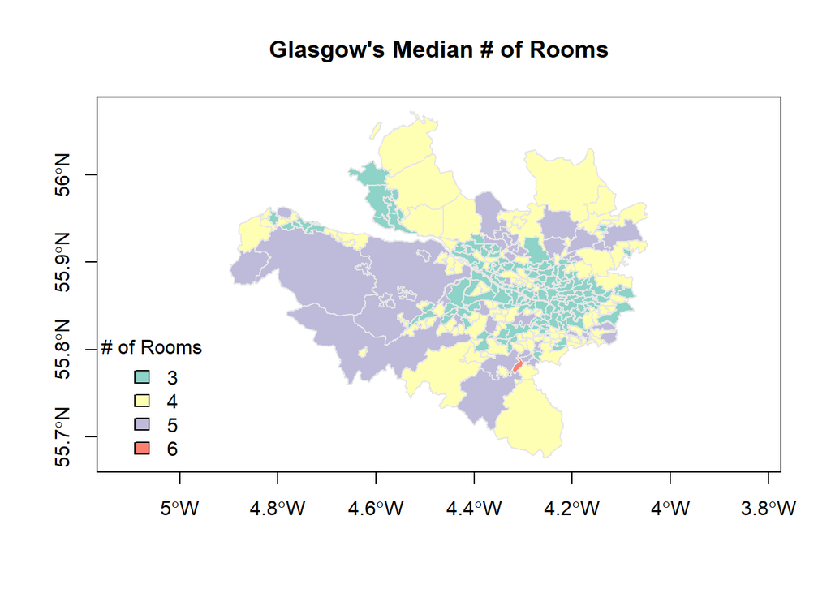

```r
Glasgow.df$MEDROOM <- factor(Glasgow.df$MEDROOM)
plot(Glasgow.shp, axes=T, col=grey(0.9), border="white",
     xlim=glasgow.bbox[1,],ylim=glasgow.bbox[2,])
plotColorQual(Glasgow.df$MEDROOM,Glasgow.shp,
              my.title="Glasgow's Median # of Rooms",
              my.legend="# of Rooms",addToMap=T)
```

*There seems to be a clustering of a median of 3 rooms around the main city center; while there is a distribution of a median of 4 rooms throughout the north, northeast, southwest, and south areas of the city, in addition to a couple throughout the city center. The median of 5 rooms is mostly clustered in the northwest part of the city. The median with 6 rooms is located in the southwest part of the city in a very small area. Essentially, this might be a wealthy area due to the median rooms being highest, which would mean bigger dwellings are located there.*

*Chloropath map of **Crime rate** variable*

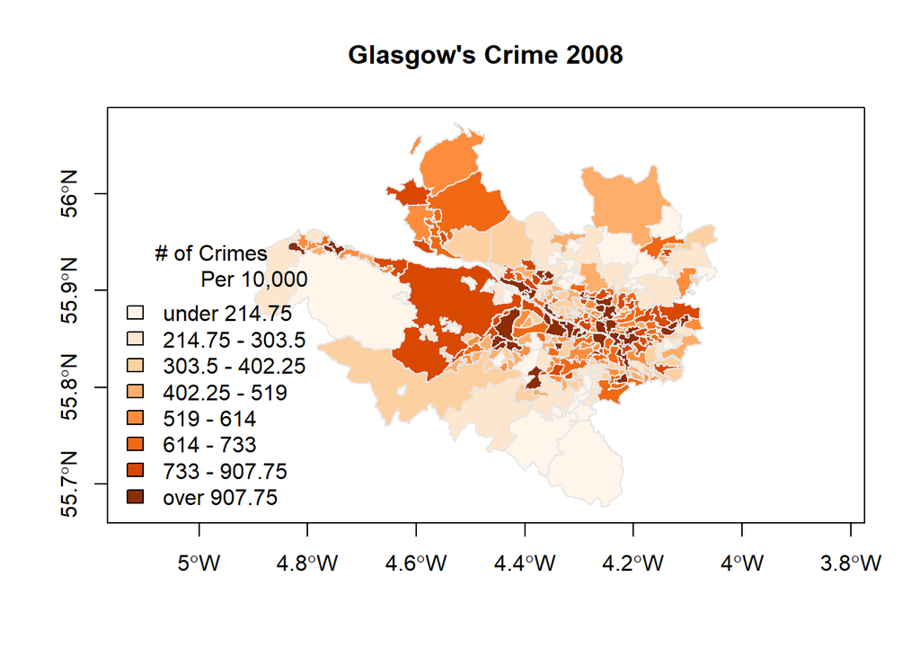

```r
plot(Glasgow.shp,axes=T,col=grey(0.9),border="white",
     xlim=glasgow.bbox[1,],ylim=glasgow.bbox[2,])
plotColorRamp(Glasgow.df$CRIME,Glasgow.shp,n.breaks=8,
              my.title="Glasgow's Crime 2008",
              my.legend=
              "# of Crimes
              Per 10,000",addToMap=T)
```

*Common sense argument tells us that crime tends to be higher around the main city center; this argument holds true for Glasgow. If this map would be overlaid with the freeways, we’d be able to see that the freeways run along the darker areas of our map. The far outskirts in the south and northwest present the least crime. In addition, a couple areas to the east have low crime rates. Furthermore, there is a lot of crime along where the river runs in addition to the southeast.*

*Chloropath map of **Property Sales** variable*

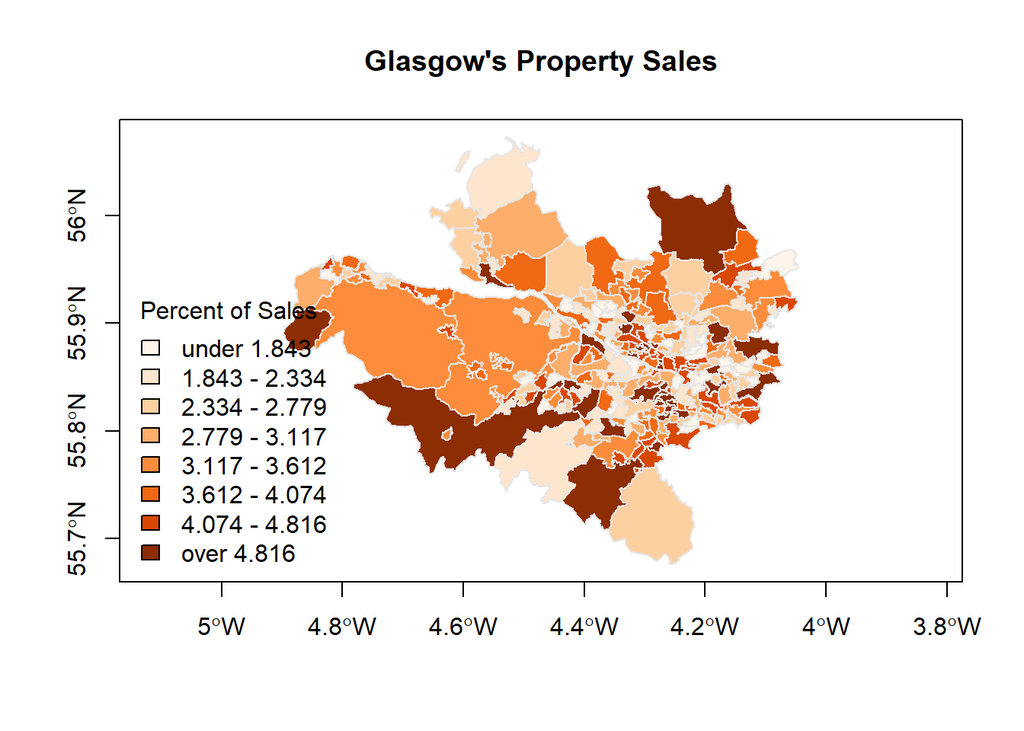

```r
plot(Glasgow.shp,axes=T,col=grey(0.9),border="white",
     xlim=glasgow.bbox[1,],ylim=glasgow.bbox[2,])
plotColorRamp(Glasgow.df$SALES,Glasgow.shp,n.breaks=8,
              my.title="Glasgow's Property Sales",
              my.legend="Percent of Sales",addToMap=T)
```

*There is a lot of movement in some IGs in the northeast tip, southwest tips, and northwest tip. The areas closer to the main city center are a mixture or high percent of sales versus low percent of sales. I would argue that since Glasgow is a popular city the high sales closer to the main city center is due to people moving in and out of the city from other cities and countries. The high sales throughout the outskirts of the city are in relatively very safe IGs, therefore I would conclude that a lot of young people who are starting families are moving out from the city center to the outskirts into detached homes vs their city flats.*

*Chloropath map of **Income Deprived Population** variable*

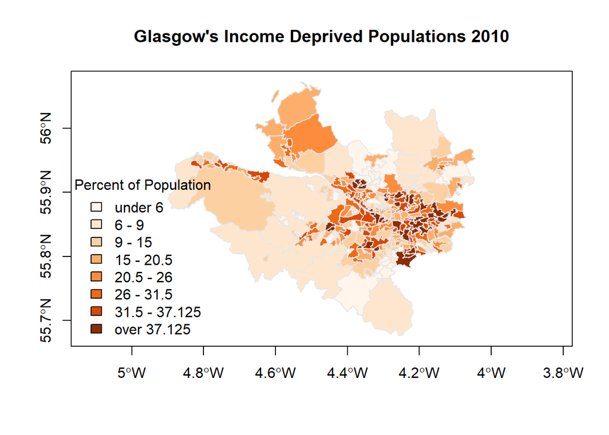

```r
plot(Glasgow.shp,axes=T,col=grey(0.9),border="white",
     xlim=glasgow.bbox[1,],ylim=glasgow.bbox[2,])
plotColorRamp(Glasgow.df$INCOMEDEP,Glasgow.shp,n.breaks=8,
              my.title="Glasgow's Income Deprived Populations 2010",
              my.legend="Percent of Population",addToMap=T)
```

*The majority of the income deprived populations are concentrated in the southeast of the city. This area is also concentrated with flat with a median room number of 3. The population in this cluster is living there not by choice, but by their financial constraints. However, some parts of the high income deprived population cluster has low crime, which I would argue is contributed by the fact that there is some green space there.*

## Building Regression Model

```r
Glasgowlm <- lm(MEDPRICE~MEDROOM+CRIME+SALES+TYPE+INCOMEDEP, data=Glas.frame)
summary(Glasgowlm)
```

```
##
## Call:
## lm(formula = MEDPRICE ~ MEDROOM + CRIME + SALES + TYPE + INCOMEDEP,
##     data = Glas.frame)
##
## Residuals:
##    Min     1Q Median     3Q    Max
## -74942 -20494  -3631  16794 118689
##
## Coefficients:
##               Estimate Std. Error t value Pr(>|t|)
## (Intercept)  82096.082  23916.540   3.433 0.000694 ***
## MEDROOM      24981.720   4367.370   5.720 2.89e-08 ***
## CRIME            3.330      3.991   0.835 0.404751
## SALES         6010.901   1650.325   3.642 0.000325 ***
## TYPEflat    -34714.320   8508.382  -4.080 5.98e-05 ***
## TYPEsemi    -34743.023   8234.529  -4.219 3.38e-05 ***
## TYPEterrace -49179.497  10017.236  -4.909 1.60e-06 ***
## INCOMEDEP    -1382.506    254.561  -5.431 1.28e-07 ***
## ---
## Signif. codes:  0 '***' 0.001 '**' 0.01 '*' 0.05 '.' 0.1 ' ' 1
##
## Residual standard error: 32650 on 263 degrees of freedom
## Multiple R-squared:  0.6359, Adjusted R-squared:  0.6262
## F-statistic: 65.62 on 7 and 263 DF,  p-value: < 2.2e-16
```

## Verifying multicollinearity

Multicollinearity is defined as a phenomenon where any number of predictor variables are highly correlated, and therefore, one can be predicted from the others with high accuracy. GVIF has come into play for our multicollinearity test because TYPE is a factor and has more than one degree of freedom as well as more than one coefficient. The rule of GVIF^(1/(2*Df)) is that less than 2 is a good rule of thumb, which essentially equals a VIF of 4 for one coefficient variables. As a result, we are not presented with a multicollinearity problem.

```r
vif(Glasgowlm)
```

```
##               GVIF Df GVIF^(1/(2*Df))
## MEDROOM   2.559653  1        1.599892
## CRIME     1.274597  1        1.128980
## SALES     1.361759  1        1.166944
## TYPE      2.337473  3        1.152014
## INCOMEDEP 2.667516  1        1.633253
```

## Residual analysis

The Shapiro Wilk test is used to test if the residuals are normally distributed. To say that residuals are normally distributed, the p value needs to be above 0.05.

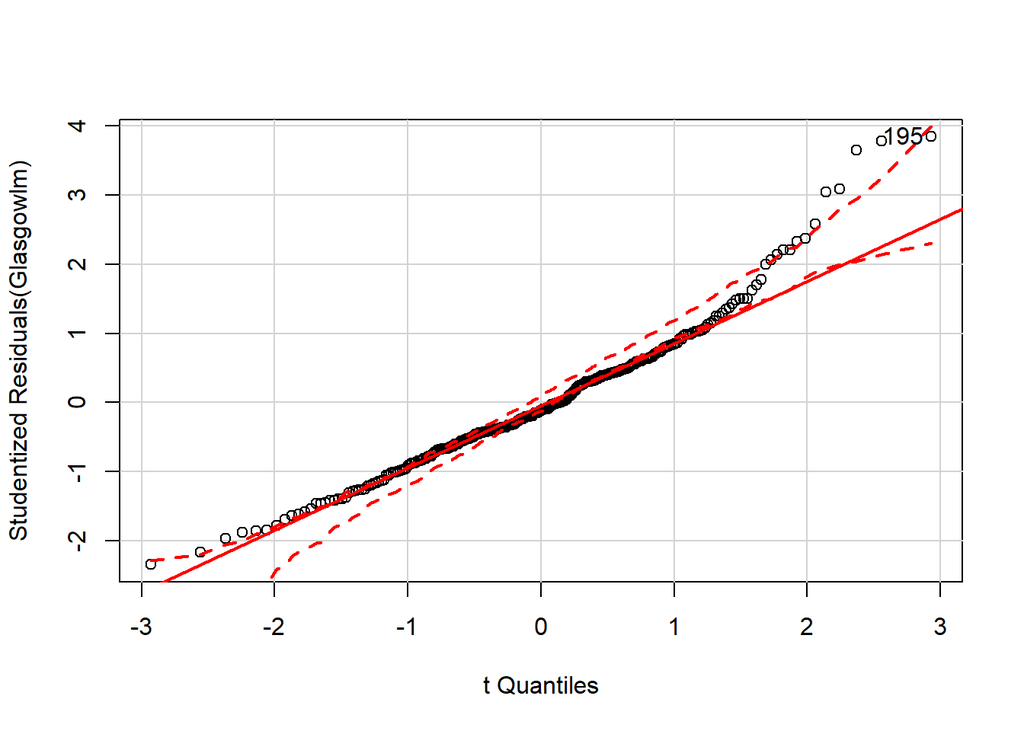

```
## 195
## 271
```

```r
qqPlot(Glasgowlm, id.n = 1)
```

```r
resGlas <- residuals(Glasgowlm)
shapiro.test(resGlas)
```

```
##
##  Shapiro-Wilk normality test
##
## data:  resGlas
## W = 0.96477, p-value = 3.423e-06
```

Hence a small p-value indicates that we should reject the null hypothesis and conclude that the residuals are not normally distributed.

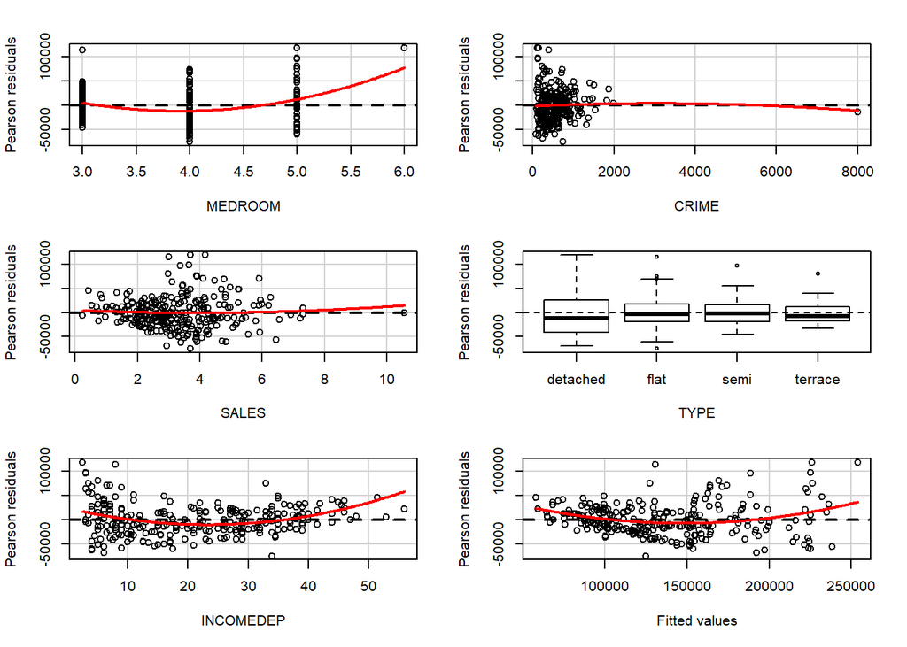

```
##            Test stat Pr(>|t|)
## MEDROOM        6.043    0.000
## CRIME         -0.865    0.388
## SALES          0.696    0.487
## TYPE              NA       NA
## INCOMEDEP      6.530    0.000
## Tukey test     7.947    0.000
```

```r
residualPlots(Glasgowlm)
```

As the pvalues of Independent variables “MEDROOM”, “INCOMEDEP” are less that 0.05 (pvalue < 0.05), these variables needed to be transformed.

## Analyzing outliers and Influencial cases

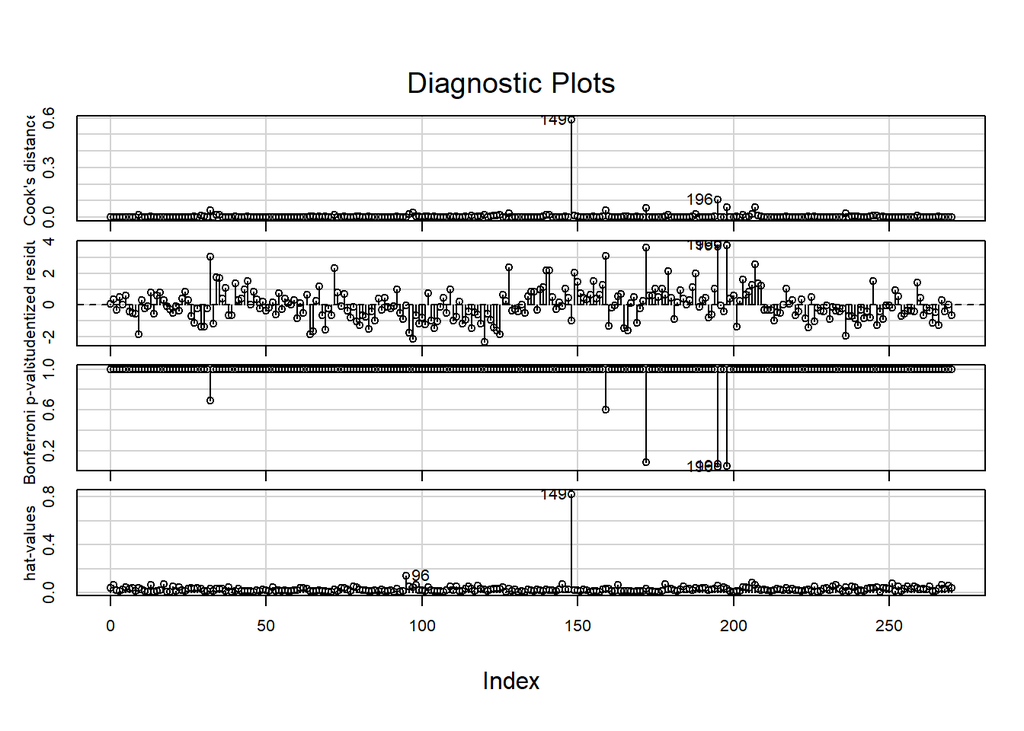

```r
influenceIndexPlot(Glasgowlm, vars=c("Cook", "Studentized", "Bonf", "hat"),    main="Diagnostic Plots", labels=NULL, id.n=2, id.method = "y")
```

### Outcome of the first model

1. Independent varaibles ‘CRIME’ is not significant (from summary(model))
2. Independent variables ‘MEDPRICE’, ‘MEDROOM’, ‘INCOMEDEP’ has to be transformed (from residualplots)

## Model Revision 1

CRIME is dropped from the earlier model.

```r
Glasgowlm_OCrime <- lm(MEDPRICE~MEDROOM+SALES+TYPE+INCOMEDEP, data=Glas.frame)
summary(Glasgowlm_OCrime)
```

```
##
## Call:
## lm(formula = MEDPRICE ~ MEDROOM + SALES + TYPE + INCOMEDEP, data = Glas.frame)
##
## Residuals:
##    Min     1Q Median     3Q    Max
## -74918 -20114  -3722  16646 119174
##
## Coefficients:
##             Estimate Std. Error t value Pr(>|t|)
## (Intercept)  84613.3    23711.9   3.568 0.000426 ***
## MEDROOM      24517.6     4329.3   5.663 3.87e-08 ***
## SALES         6057.7     1648.4   3.675 0.000288 ***
## TYPEflat    -34362.0     8493.0  -4.046 6.85e-05 ***
## TYPEsemi    -34849.6     8228.8  -4.235 3.16e-05 ***
## TYPEterrace -49430.0    10007.0  -4.940 1.39e-06 ***
## INCOMEDEP    -1346.0      250.6  -5.370 1.72e-07 ***
## ---
## Signif. codes:  0 '***' 0.001 '**' 0.01 '*' 0.05 '.' 0.1 ' ' 1
##
## Residual standard error: 32630 on 264 degrees of freedom
## Multiple R-squared:  0.6349, Adjusted R-squared:  0.6266
## F-statistic: 76.53 on 6 and 264 DF,  p-value: < 2.2e-16
```

*Result* Now, all the indepedent variables are highly significant.

Evaluation of the model by using anova F test

```r
Anova(Glasgowlm_OCrime, Glasgowlm)
```

```
## Anova Table (Type II tests)
##
## Response: MEDPRICE
##               Sum Sq  Df F value    Pr(>F)
## MEDROOM   3.4153e+10   1 32.0344 3.954e-08 ***
## SALES     1.4381e+10   1 13.4892 0.0002906 ***
## TYPE      3.0748e+10   3  9.6137 4.811e-06 ***
## INCOMEDEP 3.0714e+10   1 28.8088 1.755e-07 ***
## Residuals 2.8039e+11 263
## ---
## Signif. codes:  0 '***' 0.001 '**' 0.01 '*' 0.05 '.' 0.1 ' ' 1
```

## Lets talk about transformations now

*The following image illustrates the process of transformation* [Source](http://stattrek.com/regression/linear-transformation.aspx?Tutorial=AP)

Image:

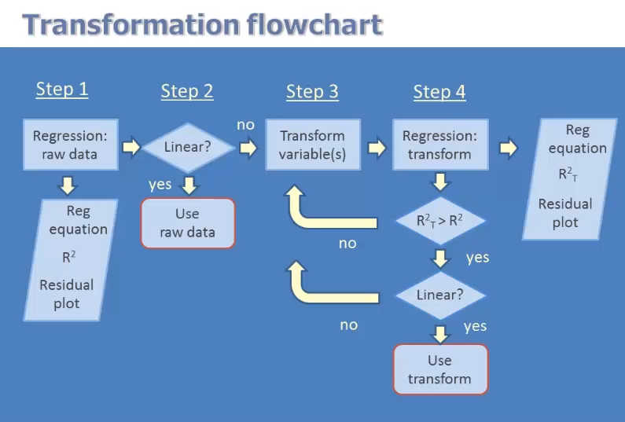

```r
Glasgowlm_log <- lm(log(MEDPRICE) ~ MEDROOM+SALES+TYPE+INCOMEDEP, data=Glas.frame)
summary(Glasgowlm_log)
```

```
##
## Call:
## lm(formula = log(MEDPRICE) ~ MEDROOM + SALES + TYPE + INCOMEDEP,
##     data = Glas.frame)
##
## Residuals:
##      Min       1Q   Median       3Q      Max
## -0.81654 -0.14849 -0.01206  0.14009  0.63163
##
## Coefficients:
##              Estimate Std. Error t value Pr(>|t|)
## (Intercept) 11.529990   0.153984  74.878  < 2e-16 ***
## MEDROOM      0.125912   0.028114   4.479 1.12e-05 ***
## SALES        0.048184   0.010705   4.501 1.01e-05 ***
## TYPEflat    -0.183403   0.055153  -3.325  0.00101 **
## TYPEsemi    -0.150869   0.053438  -2.823  0.00512 **
## TYPEterrace -0.271951   0.064985  -4.185 3.89e-05 ***
## INCOMEDEP   -0.011523   0.001628  -7.080 1.31e-11 ***
## ---
## Signif. codes:  0 '***' 0.001 '**' 0.01 '*' 0.05 '.' 0.1 ' ' 1
##
## Residual standard error: 0.2119 on 264 degrees of freedom
## Multiple R-squared:  0.6562, Adjusted R-squared:  0.6484
## F-statistic: 83.97 on 6 and 264 DF,  p-value: < 2.2e-16
```

```r
vif(Glasgowlm_log)
```

```
##               GVIF Df GVIF^(1/(2*Df))
## MEDROOM   2.518144  1        1.586866
## SALES     1.360184  1        1.166269
## TYPE      2.313505  3        1.150037
## INCOMEDEP 2.588699  1        1.608944
```

```r
resGlas_log <- residuals(lm(log(MEDPRICE) ~ MEDROOM+SALES+TYPE+INCOMEDEP, data=Glas.frame))
shapiro.test(resGlas_log)
```

```
##
##  Shapiro-Wilk normality test
##
## data:  resGlas_log
## W = 0.99359, p-value = 0.3018
```

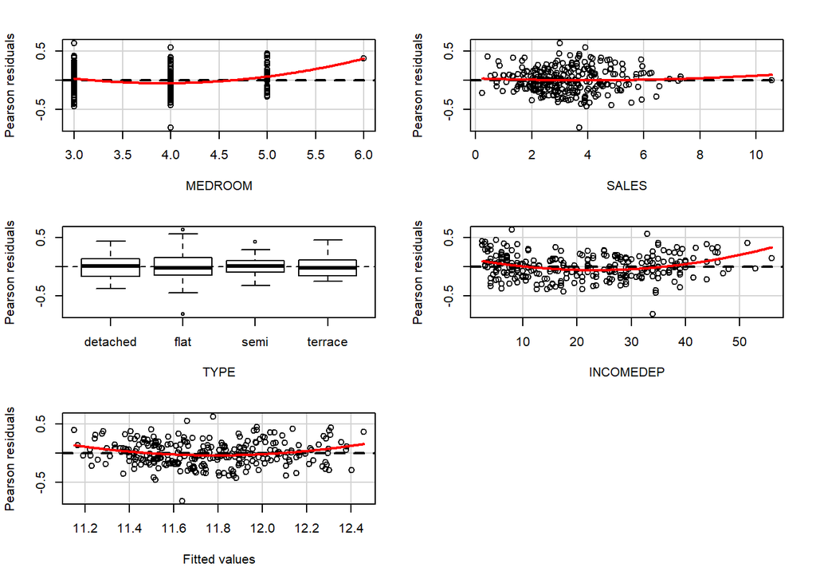

```
##            Test stat Pr(>|t|)
## MEDROOM        4.228    0.000
## SALES          0.662    0.508
## TYPE              NA       NA
## INCOMEDEP      5.613    0.000
## Tukey test     5.344    0.000
```

```r
residualPlots(Glasgowlm_log)
```

```r
Glasgowlm_log2 <- lm(log(MEDPRICE) ~ log(MEDROOM)+SALES+TYPE+log(INCOMEDEP), data=Glas.frame)
summary(Glasgowlm_log2)
```

```
##
## Call:
## lm(formula = log(MEDPRICE) ~ log(MEDROOM) + SALES + TYPE + log(INCOMEDEP),
##     data = Glas.frame)
##
## Residuals:
##      Min       1Q   Median       3Q      Max
## -0.76410 -0.12827 -0.00245  0.14006  0.61218
##
## Coefficients:
##                 Estimate Std. Error t value Pr(>|t|)
## (Intercept)    12.136955   0.196832  61.661  < 2e-16 ***
## log(MEDROOM)    0.257607   0.101352   2.542   0.0116 *
## SALES           0.049094   0.009483   5.177 4.47e-07 ***
## TYPEflat       -0.081527   0.053497  -1.524   0.1287
## TYPEsemi       -0.112851   0.049544  -2.278   0.0235 *
## TYPEterrace    -0.146207   0.062597  -2.336   0.0203 *
## log(INCOMEDEP) -0.286379   0.027979 -10.236  < 2e-16 ***
## ---
## Signif. codes:  0 '***' 0.001 '**' 0.01 '*' 0.05 '.' 0.1 ' ' 1
##
## Residual standard error: 0.1977 on 264 degrees of freedom
## Multiple R-squared:  0.7007, Adjusted R-squared:  0.6939
## F-statistic:   103 on 6 and 264 DF,  p-value: < 2.2e-16
```

```r
vif(Glasgowlm_log2)
```

```
##                    GVIF Df GVIF^(1/(2*Df))
## log(MEDROOM)   2.592381  1        1.610087
## SALES          1.226130  1        1.107308
## TYPE           2.534545  3        1.167661
## log(INCOMEDEP) 3.140697  1        1.772201
```

```r
resGlas_log2 <- residuals(lm(log(MEDPRICE) ~ log(MEDROOM)+CRIME+SALES+TYPE+log(INCOMEDEP), data=Glas.frame))
shapiro.test(resGlas_log2)
```

```
##
##  Shapiro-Wilk normality test
##
## data:  resGlas_log2
## W = 0.99396, p-value = 0.3521
```

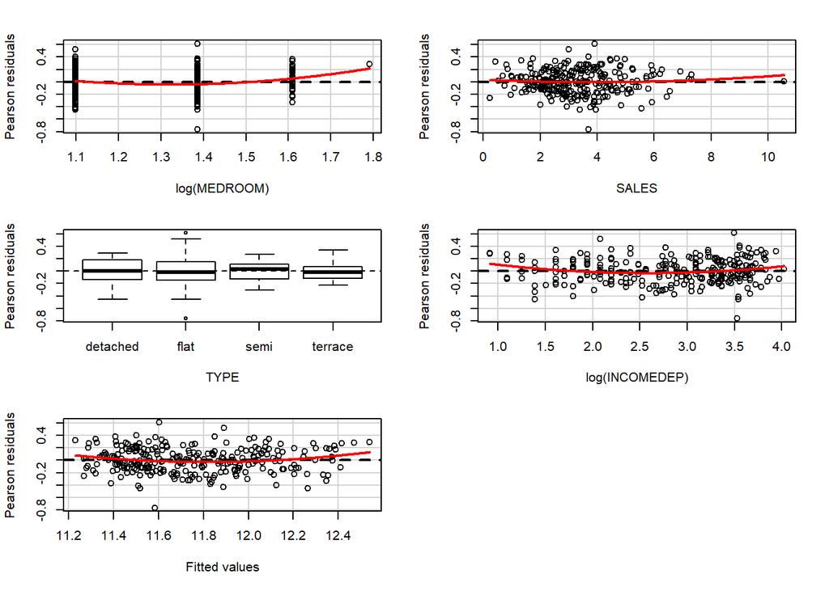

```
##                Test stat Pr(>|t|)
## log(MEDROOM)       3.297    0.001
## SALES              0.838    0.403
## TYPE                  NA       NA
## log(INCOMEDEP)     2.860    0.005
## Tukey test         3.027    0.002
```

```r
residualPlots(Glasgowlm_log2)
```

```r
Glasgowlm_log3 <- (lm(MEDPRICE ~ MEDROOM + I(MEDROOM ^2) +  SALES + TYPE+ INCOMEDEP + (INCOMEDEP^2), data=Glas.frame))
summary(Glasgowlm_log3)
```

```
##
## Call:
## lm(formula = MEDPRICE ~ MEDROOM + I(MEDROOM^2) + SALES + TYPE +
##     INCOMEDEP + (INCOMEDEP^2), data = Glas.frame)
##
## Residuals:
##    Min     1Q Median     3Q    Max
## -66524 -19346  -2547  14540 111808
##
## Coefficients:
##               Estimate Std. Error t value Pr(>|t|)
## (Intercept)   423121.3    59695.3   7.088 1.25e-11 ***
## MEDROOM      -160875.7    30612.3  -5.255 3.06e-07 ***
## I(MEDROOM^2)   23822.8     3898.9   6.110 3.57e-09 ***
## SALES           5998.6     1545.5   3.881 0.000131 ***
## TYPEflat      -21435.7     8239.0  -2.602 0.009801 **
## TYPEsemi      -21518.1     8017.6  -2.684 0.007740 **
## TYPEterrace   -30091.7     9901.6  -3.039 0.002612 **
## INCOMEDEP      -1500.0      236.3  -6.347 9.56e-10 ***
## ---
## Signif. codes:  0 '***' 0.001 '**' 0.01 '*' 0.05 '.' 0.1 ' ' 1
##
## Residual standard error: 30600 on 263 degrees of freedom
## Multiple R-squared:  0.6803, Adjusted R-squared:  0.6718
## F-statistic: 79.96 on 7 and 263 DF,  p-value: < 2.2e-16
```

```r
resGlas_log3 <- residuals(lm(log(MEDPRICE) ~ MEDROOM +  SALES + I(SALES^0.5) +TYPE+ INCOMEDEP  + I(INCOMEDEP^0.5), data=Glas.frame))
shapiro.test(resGlas_log3)
```

```
##
##  Shapiro-Wilk normality test
##
## data:  resGlas_log3
## W = 0.99227, p-value = 0.1694
```

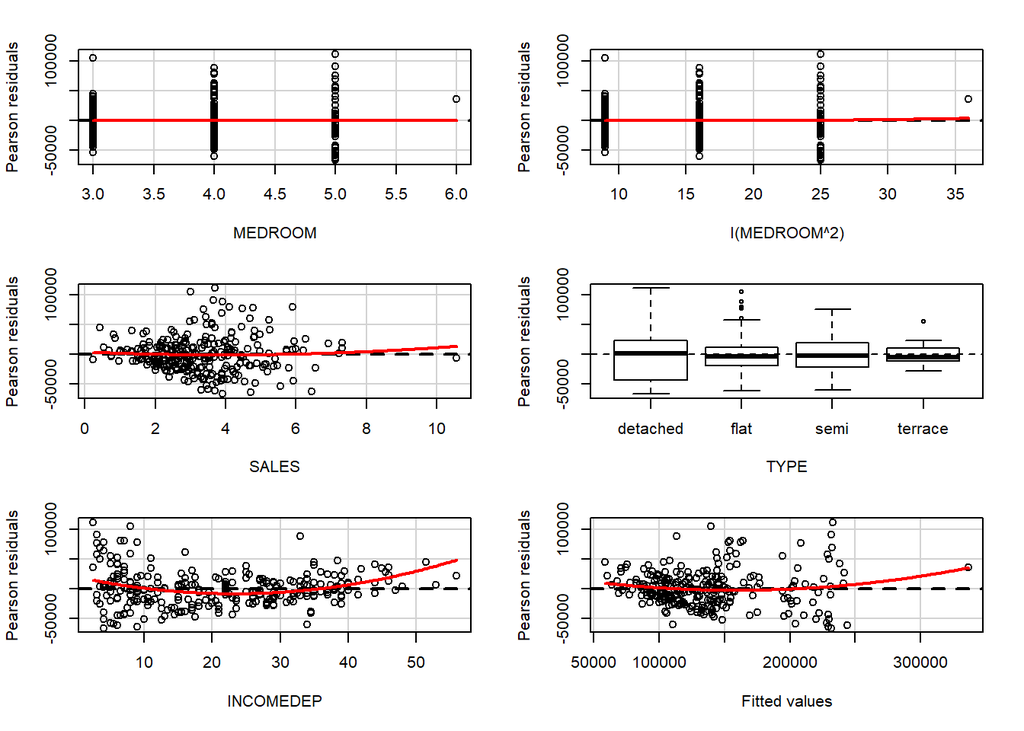

```
##              Test stat Pr(>|t|)
## MEDROOM         -0.079    0.937
## I(MEDROOM^2)     1.367    0.173
## SALES            0.712    0.477
## TYPE                NA       NA
## INCOMEDEP        5.778    0.000
## Tukey test       3.803    0.000
```

```r
residualPlots(Glasgowlm_log3)
```

```r
library(car)
library(e1071)
summary(powerTransform(cbind(MEDPRICE, MEDROOM, TYPE, SALES, INCOMEDEP) ~ 1, data = Glas.frame))
```

```
## bcPower Transformations to Multinormality
##           Est.Power Std.Err. Wald Lower Bound Wald Upper Bound
## MEDPRICE    -0.2099   0.1175          -0.4403           0.0205
## MEDROOM     -0.7732   0.3791          -1.5162          -0.0302
## TYPE         0.2209   0.1403          -0.0540           0.4958
## SALES        0.4953   0.0850           0.3287           0.6619
## INCOMEDEP    0.3045   0.0757           0.1561           0.4530
##
## Likelihood ratio tests about transformation parameters
##                                            LRT df         pval
## LR test, lambda = (0 0 0 0 0)        64.615830  5 1.346367e-12
## LR test, lambda = (1 1 1 1 1)       287.248174  5 0.000000e+00
## LR test, lambda = (0 -1 0 0.5 0.33)   6.533545  5 2.577050e-01
```

```r
lamda.Pri <- 0; lamda.MEDR <- -1; lamda.SALE <- 0.5 ; lamda.INC <- 0.33

Glasgowlm_log4 <- (lm(log(MEDPRICE) ~ bcPower(MEDROOM, lamda.MEDR)+ MEDROOM +  bcPower(SALES, lamda.SALE) + SALES + TYPE +bcPower(INCOMEDEP, lamda.INC)+ INCOMEDEP, data=Glas.frame))
summary(Glasgowlm_log4)
```

```
##
## Call:
## lm(formula = log(MEDPRICE) ~ bcPower(MEDROOM, lamda.MEDR) + MEDROOM +
##     bcPower(SALES, lamda.SALE) + SALES + TYPE + bcPower(INCOMEDEP,
##     lamda.INC) + INCOMEDEP, data = Glas.frame)
##
## Residuals:
##      Min       1Q   Median       3Q      Max
## -0.74687 -0.13324 -0.00788  0.14852  0.63152
##
## Coefficients:
##                                Estimate Std. Error t value Pr(>|t|)
## (Intercept)                   13.787974   0.735297  18.752  < 2e-16 ***
## bcPower(MEDROOM, lamda.MEDR)  -3.835883   1.648948  -2.326  0.02077 *
## MEDROOM                        0.355026   0.121727   2.917  0.00385 **
## bcPower(SALES, lamda.SALE)    -0.009213   0.091732  -0.100  0.92008
## SALES                          0.061983   0.049029   1.264  0.20729
## TYPEflat                      -0.020126   0.055060  -0.366  0.71501
## TYPEsemi                      -0.055456   0.051128  -1.085  0.27907
## TYPEterrace                   -0.052458   0.066593  -0.788  0.43157
## bcPower(INCOMEDEP, lamda.INC) -0.233079   0.040166  -5.803 1.88e-08 ***
## INCOMEDEP                      0.017614   0.005480   3.214  0.00147 **
## ---
## Signif. codes:  0 '***' 0.001 '**' 0.01 '*' 0.05 '.' 0.1 ' ' 1
##
## Residual standard error: 0.1938 on 261 degrees of freedom
## Multiple R-squared:  0.7158, Adjusted R-squared:  0.706
## F-statistic: 73.03 on 9 and 261 DF,  p-value: < 2.2e-16
```

```r
resGlas_4 <- residuals(Glasgowlm_log4)
shapiro.test(resGlas_4)
```

```
##
##  Shapiro-Wilk normality test
##
## data:  resGlas_4
## W = 0.99354, p-value = 0.2962
```

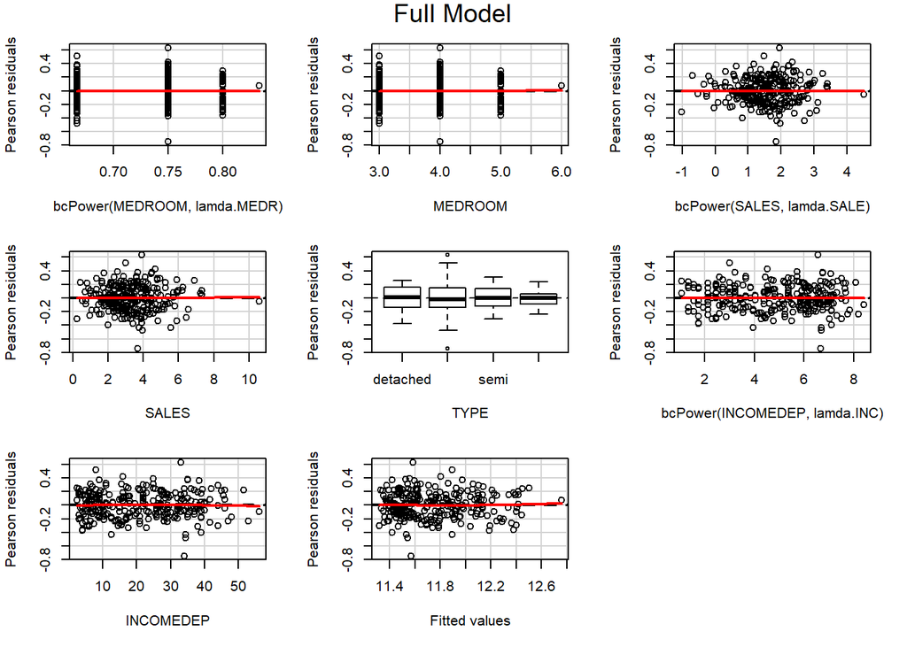

```
##                               Test stat Pr(>|t|)
## bcPower(MEDROOM, lamda.MEDR)     -0.417    0.677
## MEDROOM                           0.417    0.677
## bcPower(SALES, lamda.SALE)       -0.623    0.534
## SALES                             0.263    0.793
## TYPE                                 NA       NA
## bcPower(INCOMEDEP, lamda.INC)     0.611    0.542
## INCOMEDEP                        -0.626    0.532
## Tukey test                        0.600    0.548
```

```r
residualPlots(Glasgowlm_log4, main = "Full Model")
```

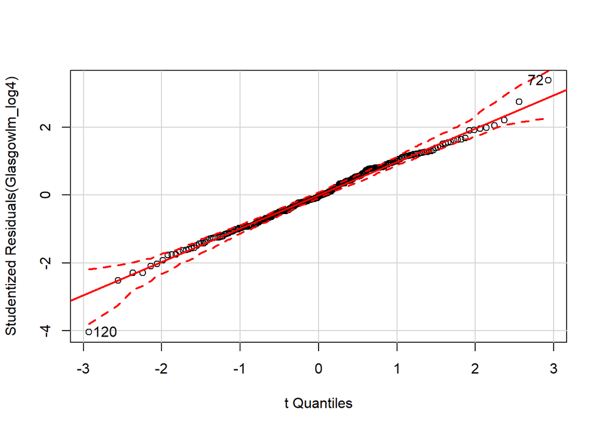

```
## 120  72
##   1 271
```

```r
qqPlot(Glasgowlm_log4, id.n = 2)
```

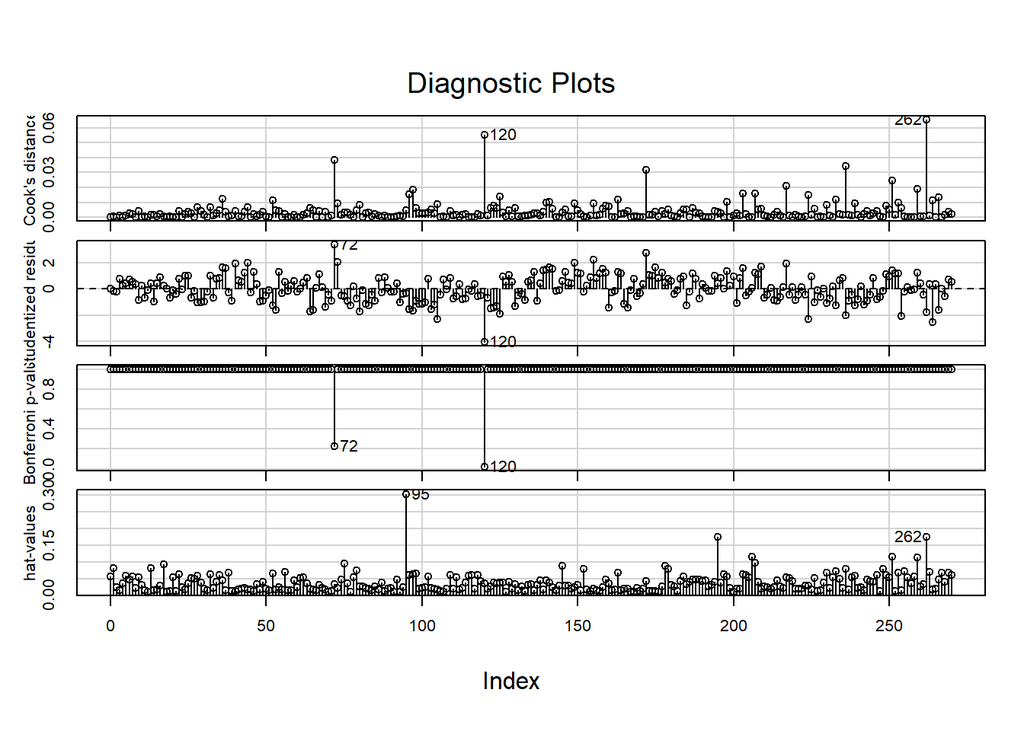

```r
influenceIndexPlot(Glasgowlm_log4, id.n = 2)
```

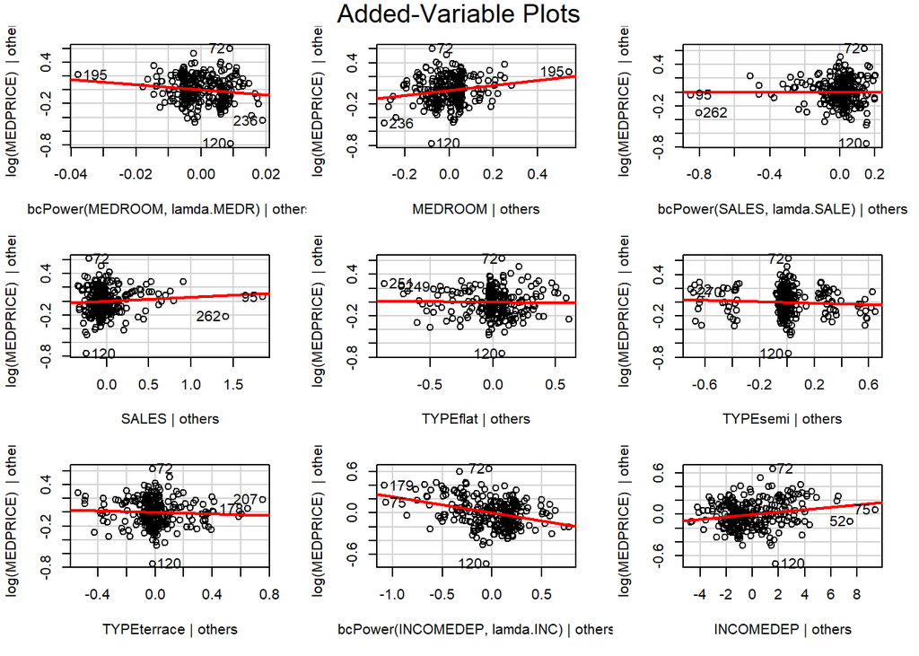

```r
avPlots(Glasgowlm_log4, id.n = 2)
```